# Psychometric modeling of the Syntactic Complexity Scale of the CDI

Seamus Donnelly

```r
library(wordbankr) # WB data
library(tidyverse) # tidy
library(mirt) # IRT models
library(ltm) # more IRT functions
library(psych) # some psychometric stuff (tests of dimensionality)
library(Gifi)# some more psychometric stuff (tests of dimensionality)
library(knitr) # some formatting, tables, etc
library(patchwork) # combining plots.
library(GGally) # More plottinng options.
library(lordif) # differential item functioning.
```

In our meeting on 28/June/2021, we noted that by adding Word Forms, we might be able to model some of the intermediate levels of syntactic proficiency between the 0 and 1 items on the complexity scale. I’m going to start with adding word endings and combines as those seem like the most straight forward. The problem with the word forms and word endings is that we expect them to by non-monotonically related to language proficiency, so I’m no sure how well they’ll fit this model. I’ve also made a new branch on github because I realized I could maintain the ordinal scale of the ordinal items, and use an ordinal IRT model – since binary items are just ordinal items with 2 categories. This appears to be working alright, but I want to keep it in a second branch until I verify this is appropriate (I’m 95% sure it’s right).

Download data from Word Bank:

```r
Inst <- get_instrument_data(language="English (American)", form="WS")
Admin <- get_administration_data(language="English (American)", form="WS")
Item <- get_item_data(language="English (American)", form = "WS")
```

The American English CDI data has 7 types of items other than words, which are also listed in the code above: *combine*, *complexity*, *word_endings*, *word_forms_nouns*, *word_forms_verbs*, *word_endings_nouns*, and *word_endings_verbs*. The *word_endings* type seems to be questions about how often a child applies a particular morphological rule (e.g., adding an s to possessives). The *word_forms_verbs* and *word_forms_nouns* seem to be about whether a child can produce specific irregular past tenses or plurals. The *word_endings_nouns* and *word_endings_verbs* seem to be about overregularizations on nouns and verbs.

Combine data sets. Create binary variable for accuracy.

```r
Complex <- Admin %>%
  full_join(.,Inst, by="data_id") %>%
  full_join(., Item, by="num_item_id") %>%
  filter(longitudinal==FALSE) %>%
  filter(type == "combine" |
           type == "complexity" |
           type == "word_endings" |
           type== "word_forms_nouns" |
           type == "word_forms_verbs" |
           type == "word_endings_nouns" |
           type == "word_endings_verbs"
         ) %>%
  mutate(
    out = ifelse(value=="complex" | value=="sometimes" | value=="produces", yes=1,
                 no = ifelse(value=="often", yes=2, no =0))
  )
```

As a quick sanity check, let’s see which items have ordinal data (to make sure the above code worked correctly).

```r
Complex %>%
  filter(value=="often") %>%
  group_by(definition) %>%
  count()
```

| definition | n |
| --- | --- |
| ed | 155 |
| has your child begun to combine word yet? | 1390 |
| ing | 403 |
| splural | 797 |
| spossess | 1048 |

Ok, it’s only the combine variable and word endings variables – that’s right.

## 0.1 Data Screening

Let’s see how many missing values there are.

```r
Complex %>%
  filter(is.na(out)) %>%
  group_by(definition) %>%
  count()
```

| definition | n |
| --- | --- |
| ate | 1428 |
| ated | 1427 |
| baby blanket / baby's blanket | 1426 |
| baby crying / baby crying cuz she's sad | 1426 |
| baby crying / baby is crying | 1426 |
| baby want eat / baby want to eat | 1426 |
| blew | 1428 |
| blewed | 1427 |
| blockses | 1427 |
| blowed | 1427 |

[output cut: 102 more lines]

Looks like there are 1426 participants don’t have item-level complexity scores. There are a further 2 who don’t have word forms, and 1 who doesn’t have word endings.

```r
Complex$complexity_category <- ifelse(Complex$complexity_category == "", yes=Complex$type, no=Complex$complexity_category)
```

Let’s look at means and SDs for each item:

```r
Complex %>%
  filter(!is.na(out)) %>%
  group_by(definition) %>%
  summarise(
    mean=mean(out),
    sd=sd(out),
    sum=sum(out),
    category = first(complexity_category)
  ) %>%
  arrange(category) %>%
  kable(caption="Means and SDs for Each Item (Arranged by Item)")
```

Means and SDs for Each Item (Arranged by Item)

| definition | mean | sd | sum | category |
| --- | --- | --- | --- | --- |
| has your child begun to combine word yet? | 1.2833572 | 0.7960586 | 3578 | combine |
| baby blanket / baby’s blanket | 0.3873745 | 0.4872378 | 1080 | morphology |
| daddy car / daddy’s car | 0.4451220 | 0.4970684 | 1241 | morphology |
| daddy pick me up / daddy picked me up | 0.1743185 | 0.3794512 | 486 | morphology |
| doggie kiss me / doggie kissed me | 0.1879484 | 0.3907410 | 524 | morphology |
| I fall down / I fell down | 0.1807747 | 0.3849005 | 504 | morphology |
| I make tower / I making tower | 0.2360115 | 0.4247055 | 658 | morphology |
| kitty go away / kitty went away | 0.1280488 | 0.3342041 | 357 | morphology |
| kitty sleep / kitty sleeping | 0.4192970 | 0.4935326 | 1169 | morphology |
| more cookie / more cookies | 0.3758967 | 0.4844404 | 1048 | morphology |
| these my tooth / these my teeth | 0.4533716 | 0.4979103 | 1264 | morphology |
| two foot / two feet | 0.4214491 | 0.4938798 | 1175 | morphology |
| two shoe / two shoes | 0.4422525 | 0.4967431 | 1233 | morphology |
| baby crying / baby crying cuz she’s sad | 0.1599713 | 0.3666452 | 446 | syntax |
| baby crying / baby is crying | 0.1624821 | 0.3689586 | 453 | syntax |
| baby want eat / baby want to eat | 0.2650646 | 0.4414468 | 739 | syntax |
| coffee hot / that coffee hot | 0.1929699 | 0.3947004 | 538 | syntax |
| cookie mommy / cookie for mommy | 0.2413917 | 0.4280040 | 673 | syntax |
| doggie table / doggie on table | 0.3511478 | 0.4774147 | 979 | syntax |
| don’t read book / don’t want you read that book | 0.1818508 | 0.3857907 | 507 | syntax |
| go bye-bye / wanna go bye-bye | 0.2679340 | 0.4429625 | 747 | syntax |
| I like read stories / I like to read stories | 0.1779053 | 0.3825016 | 496 | syntax |
| I no do it / I can’t do it | 0.2482066 | 0.4320498 | 692 | syntax |
| I sing song / I sing song for you | 0.1449067 | 0.3520699 | 404 | syntax |
| I want that / I want that one you got | 0.1137016 | 0.3175054 | 317 | syntax |
| lookit / lookit what I got | 0.2410330 | 0.4277870 | 672 | syntax |
| lookit me / lookit me dancing | 0.2596844 | 0.4385400 | 724 | syntax |
| no wash dolly / don’t wash dolly | 0.2116212 | 0.4085310 | 590 | syntax |
| read me story Mommy / read me a story Mommy | 0.1635581 | 0.3699405 | 456 | syntax |
| that my truck / that’s my truck | 0.2822812 | 0.4501902 | 787 | syntax |

[output cut: 82 more lines]

Let’s also check the distribution of means for each category

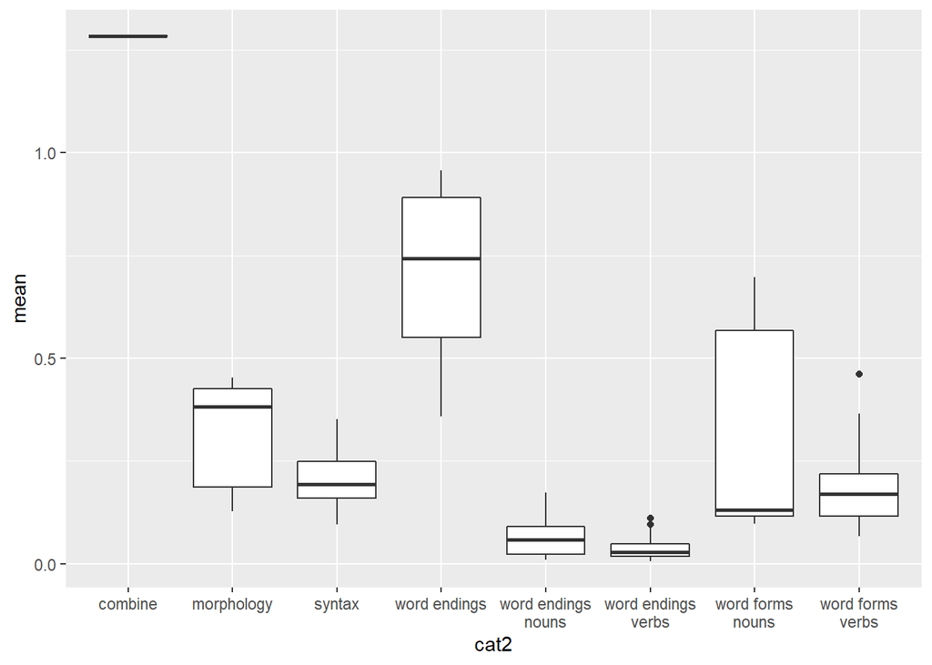

```r
Complex %>%
  filter(!is.na(out)) %>%
  group_by(definition) %>%
  summarise(
    mean=mean(out),
    category = first(complexity_category),
    cat2 = str_replace(category, "_", " " ) %>% str_replace("_", "\n" )
  ) %>%
  ggplot(aes(x=cat2, y= mean)) + geom_boxplot()
```

It seems like the word endings and the combine words variable have higher means than the morphological and syntactic complexity items (though they are ordinal, but when I treated these as binary in an older version the results were the same). The over-regularization items have very low means, and the word forms looks a bit like the syntactic and morphological complexity.

One difficulty I just thought of is that the we would expect the word form and over-regularizations to be non-monotonially related to overall grammatical proficiency, given the inverse u shaped curve we typically see in the development of morphology.

Therefore, I’m going to first add the combine item and the word endings variables, see how that changes the results of the IRT model, and then plot the over-regularization and word form scores against this, to see if we see the non-monotonicity.

## 0.2 Data Preparation

Prepare data set for IRT modeling. I’m going to re-name each item to its category (morphology or syntax) and its item number so as to make some graphs easier to read.

```r
Complex_short_with_ids <- Complex %>%
  dplyr::select(data_id, value, out, complexity_category, num_item_id) %>%
  mutate(
    label = str_c(complexity_category, num_item_id)
  ) %>%
  pivot_wider(id_cols=data_id, names_from = "label", values_from="out") %>%
  drop_na()


Complex_short <- Complex_short_with_ids %>%
  dplyr::select(starts_with(c("combine", "morphology", "syntax")), c("word_endings686", "word_endings687", "word_endings688", "word_endings689")) # dataset for IRT can't have IDs
```

## 0.3 Dimensionality Assessment

Prior to fitting the IRT model, it’s worth looking at the correlation structure of the data to get a sense of the possible dimensionality.

Create tetrachoric correlation matrix (for binary data). I created a vector with labels, for labeling of the correlation plot.

```r
Complex_poly <- polychoric(Complex_short)
```

```r
rho <- Complex_poly$rho

lab = c("1", "2", "3", "4", "5", "6", "7", "8", "9", "10", "11", "12", "13", "14", "15", "16", "17", "18", "19", "20", "21", "22", "23", "24", "25", "26", "27", "28", "29", "30", "31", "32", "33", "34", "35", "36", "37", "38", "39", "40", "41", "42") # create labels for corPlot because the defintions are long and take up a ton of space
```

Check out the correlations

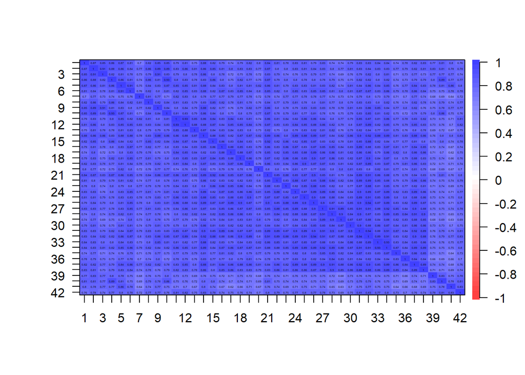

```r
corPlot(rho, labels=lab)
```

They look really high. Let’s examine the dimensionality, using princals, which is basically just a version of PCA that is appropriate for categorical data.

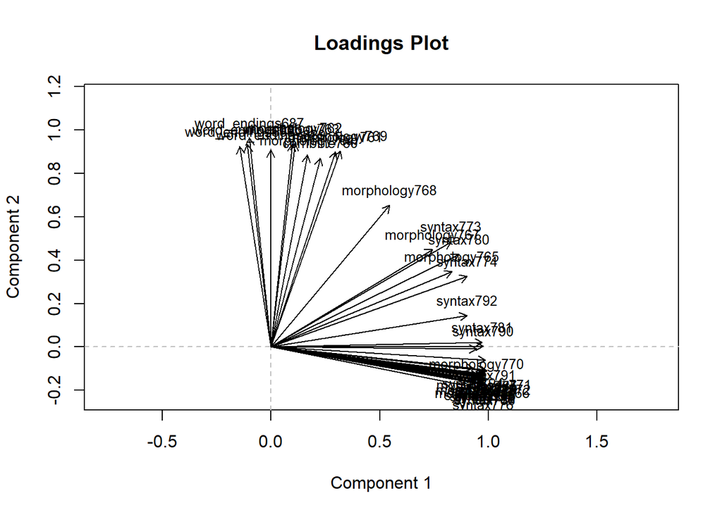

```r
pc <- princals(rho)

plot(pc)
```

Seems like there are more intermediate points in between the two clouds of vectors I saw with the earlier version of the data set. However, the plot has fipped, so that most of the vectors are pointing toward the positive first component.

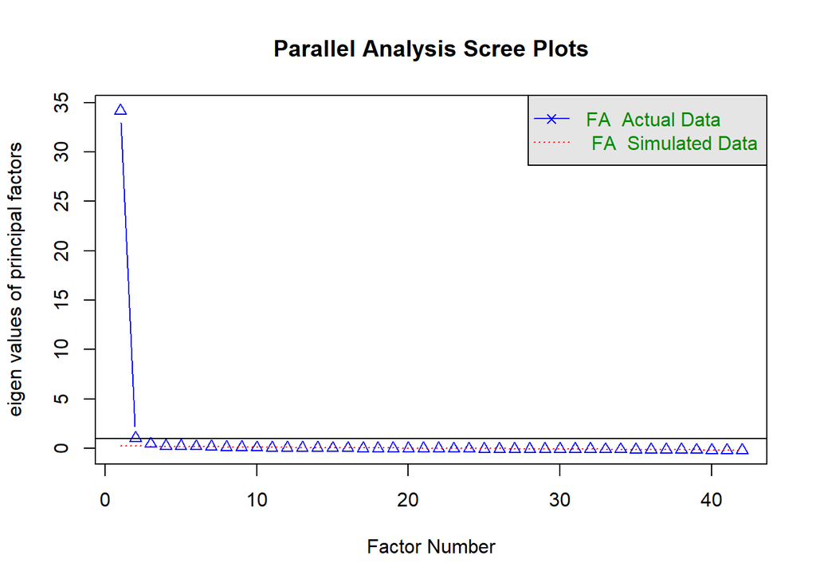

```
## Parallel analysis suggests that the number of factors =  7  and the number of components =  NA
```

```r
fa.parallel(rho, fa="fa", cor="poly", n.obs = 2785)
```

A third metric is very simple structure. This tells us the best solution assuming different values of k, where k is the maximum number of latent variables an observed variable loads on.

```r
vss(rho, cor="poly", n.obs = 2785)
```

[output not shown]

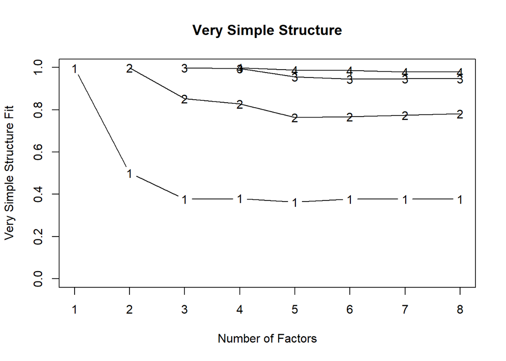

```
##
## Very Simple Structure
## Call: vss(x = rho, n.obs = 2785, cor = "poly")
## VSS complexity 1 achieves a maximimum of 1  with  1  factors
## VSS complexity 2 achieves a maximimum of 1  with  2  factors
##
## The Velicer MAP achieves a minimum of 0.02  with  3  factors
## BIC achieves a minimum of  74868.12  with  8  factors
## Sample Size adjusted BIC achieves a minimum of  76625.19  with  8  factors
##
## Statistics by number of factors
##   vss1 vss2   map dof  chisq prob sqresid fit RMSEA    BIC  SABIC complex
## 1 1.00 0.00 0.029 819 106986    0    3.38   1  0.22 100489 103092     1.0
## 2 0.50 1.00 0.018 778  96146    0    1.89   1  0.21  89975  92447     1.8
## 3 0.38 0.85 0.016 738  91813    0    1.50   1  0.21  85959  88304     2.4
## 4 0.38 0.83 0.017 699  88809    0    1.30   1  0.21  83265  85486     2.6
## 5 0.36 0.76 0.017 661  85563    0    1.10   1  0.21  80320  82421     3.0
## 6 0.38 0.77 0.017 624  82925    0    0.97   1  0.22  77975  79958     3.0
## 7 0.38 0.77 0.017 588  80796    0    0.85   1  0.22  76132  78000     3.1
## 8 0.38 0.78 0.019 553  79255    0    0.78   1  0.23  74868  76625     3.1
##   eChisq   SRMR eCRMS  eBIC
## 1   4890 0.0319 0.033 -1606
## 2   1903 0.0199 0.021 -4268
## 3   1310 0.0165 0.018 -4544
## 4   1045 0.0148 0.016 -4499
## 5    784 0.0128 0.015 -4459
## 6    631 0.0115 0.013 -4319
## 7    493 0.0101 0.012 -4171
## 8    424 0.0094 0.012 -3963
```

# 1 IRT Modeling

## 1.1 2PL model

Let’s first fit the 2pl model and examine the output.

```r
m1 <- mirt(Complex_short, 1, itemtype="graded", verbose=FALSE) # graded because we are treating all variables as ordinal.
```

```r
m1
```

```
##
## Call:
## mirt(data = Complex_short, model = 1, itemtype = "graded", verbose = FALSE)
##
## Full-information item factor analysis with 1 factor(s).
## Converged within 1e-04 tolerance after 341 EM iterations.
## mirt version: 1.33.2
## M-step optimizer: BFGS
## EM acceleration: Ramsay
## Number of rectangular quadrature: 61
## Latent density type: Gaussian
##
## Log-likelihood = -34256.68
## Estimated parameters: 89
## AIC = 68691.36; AICc = 68697.31
## BIC = 69219.31; SABIC = 68936.53
## G2 (1e+10) = 35410.77, p = 1
## RMSEA = 0, CFI = NaN, TLI = NaN
```

```r
summary(m1)
```

```
##                    F1    h2
## combine760      0.909 0.826
## morphology761   0.931 0.867
## morphology762   0.899 0.808
## morphology763   0.913 0.833
## morphology764   0.930 0.865
## morphology765   0.940 0.883
## morphology766   0.885 0.783
## morphology767   0.906 0.821
## morphology768   0.912 0.832
## morphology769   0.920 0.846
## morphology770   0.942 0.887
## morphology771   0.955 0.911
## morphology772   0.933 0.870
## syntax773       0.959 0.919
## syntax774       0.938 0.880
## syntax775       0.949 0.901
## syntax776       0.956 0.914
## syntax777       0.954 0.909
## syntax778       0.941 0.886
## syntax779       0.900 0.810
## syntax780       0.952 0.906
## syntax781       0.932 0.869
## syntax782       0.935 0.875
## syntax783       0.957 0.916
## syntax784       0.949 0.900
## syntax785       0.968 0.938
## syntax786       0.968 0.937
## syntax787       0.964 0.930
## syntax788       0.943 0.889
## syntax789       0.938 0.880
## syntax790       0.968 0.937
## syntax791       0.972 0.944
## syntax792       0.947 0.897
## syntax793       0.966 0.932
## syntax794       0.935 0.874
## syntax795       0.915 0.838
## syntax796       0.968 0.937
## syntax797       0.954 0.910
## word_endings686 0.839 0.705
## word_endings687 0.865 0.748
## word_endings688 0.845 0.714
## word_endings689 0.886 0.784
##
## SS loadings:  36.511
## Proportion Var:  0.869
##
## Factor correlations:
##
##    F1
## F1  1
```

Let’s check the overall fit of the model. The chi square statistic here isn’t super meaningful given the sample size.

```r
M2(m1)
```

|  | M2 | df | p | RMSEA | RMSEA_5 | RMSEA_95 | SRMSR | TLI | CFI |
| --- | --- | --- | --- | --- | --- | --- | --- | --- | --- |
| stats | 4657.7 | 814 | 0 | 0.04118394 | 0.04003188 | 0.04232945 | 0.06276226 | 0.9941674 | 0.9944536 |

RMSEA and CFI are good, SRMSR is a bit high but pretty reasonable. We can see if individual items misfit – i.e., do the observed cell counts differ from the expected cell counts.

```r
itemfit(m1)
```

| item | S_X2 | df.S_X2 | RMSEA.S_X2 | p.S_X2 |
| --- | --- | --- | --- | --- |
| combine760 | 46.78948 | 34 | 0.011623915 | 7.089737e-02 |
| morphology761 | 18.28756 | 32 | 0.000000000 | 9.750342e-01 |
| morphology762 | 60.16170 | 37 | 0.014995114 | 9.408782e-03 |
| morphology763 | 41.59050 | 34 | 0.008954906 | 1.737948e-01 |
| morphology764 | 38.51308 | 34 | 0.006904978 | 2.726241e-01 |
| morphology765 | 25.26072 | 38 | 0.000000000 | 9.438144e-01 |
| morphology766 | 39.84546 | 42 | 0.000000000 | 5.659568e-01 |
| morphology767 | 25.72836 | 39 | 0.000000000 | 9.494879e-01 |
| morphology768 | 38.03602 | 34 | 0.006529839 | 2.906449e-01 |
| morphology769 | 49.89838 | 37 | 0.011190051 | 7.644974e-02 |

[output cut: 32 more lines]

A few items significantly misfit. Let’s take everything with a p value less than .10. We’ll look at item gam plots of those, which plot the item response probability against the latent variable using a gam function, to look for deviations in the item-response function.

```r
misfit <- itemfit(m1) %>% # Get labels of mis-fitting items.
  filter(p.S_X2 <= .10) %>%
  dplyr::select(item) %>%
  as.vector()

items_good <- dplyr::select(Complex_short, -all_of(misfit$item)) # Well fitting items
items_bad <- dplyr::select(Complex_short, all_of(misfit$item)) # Poorly fitting items

mod_fit <- mirt(items_good, 1, "graded", verbose=FALSE) # Calculate factor scores using only the well fitting items.
Theta <- fscores(mod_fit)
```

# 2 Plot non-linear item response theory curves with the factor scores

```r
IG760 <- itemGAM(items_bad$combine760, Theta)

IG762 <- itemGAM(items_bad$morphology762,Theta)
IG769<- itemGAM(items_bad$morphology769,Theta)
IG771<- itemGAM(items_bad$morphology771,Theta)


IG775 <- itemGAM(items_bad$syntax775,Theta)
IG776 <- itemGAM(items_bad$syntax776,Theta)
IG785 <- itemGAM(items_bad$syntax785,Theta)
IG787<- itemGAM(items_bad$syntax787,Theta)

IG688 <- itemGAM(items_bad$word_endings688,Theta)
IG689<- itemGAM(items_bad$word_endings689,Theta)
```

Combine

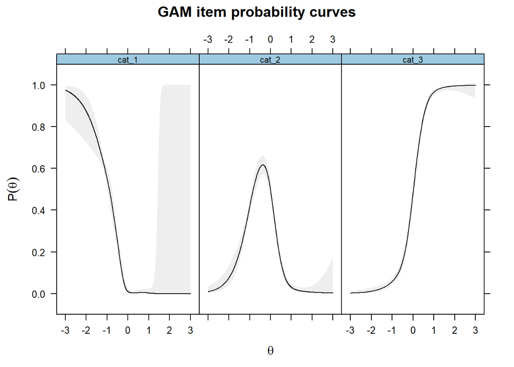

```r
plot(IG760)
```

Flattens out pretty quickly at a difficulty of 0.

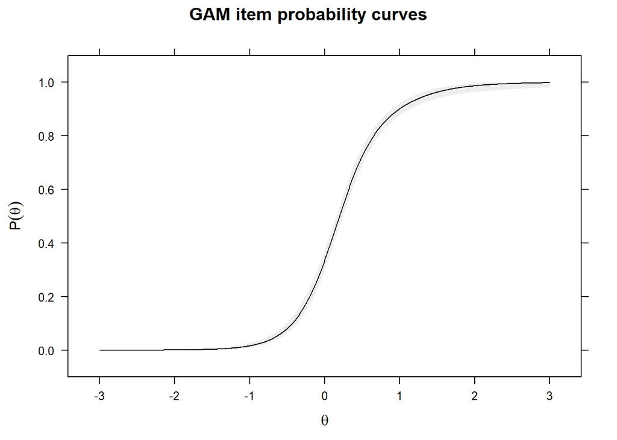

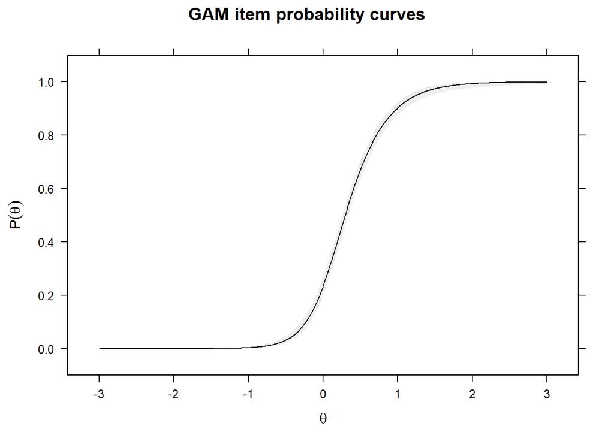

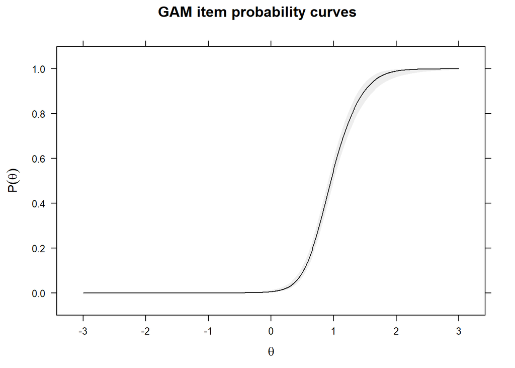

```r
plot(IG762); plot(IG769); plot(IG771)
```

Syntax items

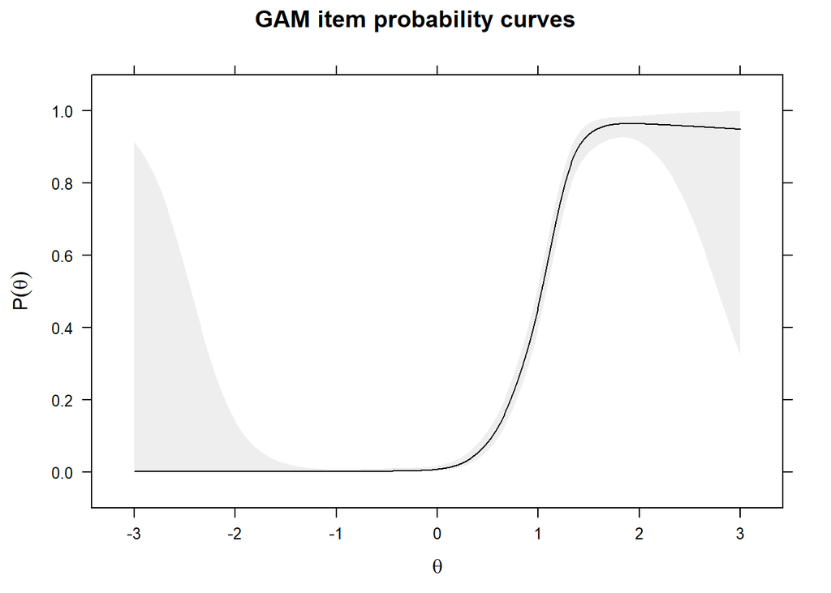

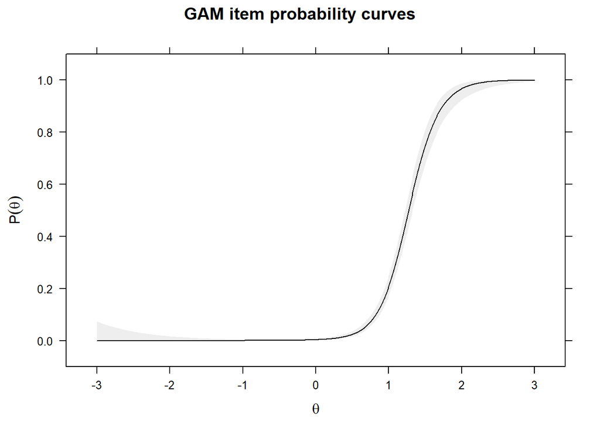

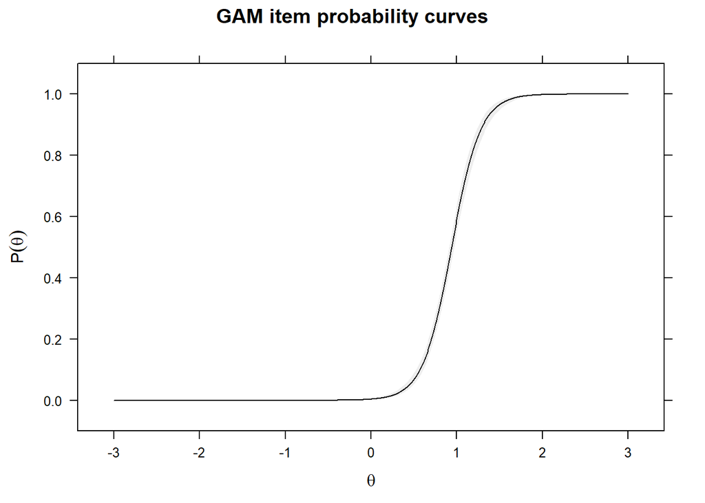

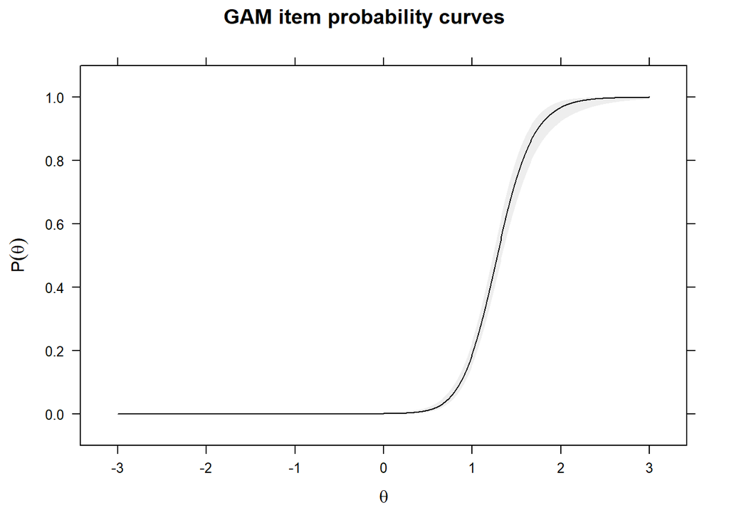

```r
plot(IG775); plot(IG776); plot(IG785); plot(IG787)
```

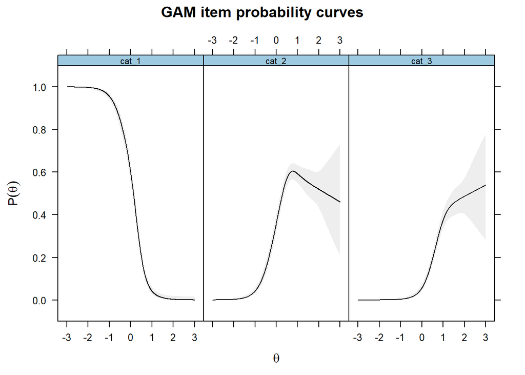

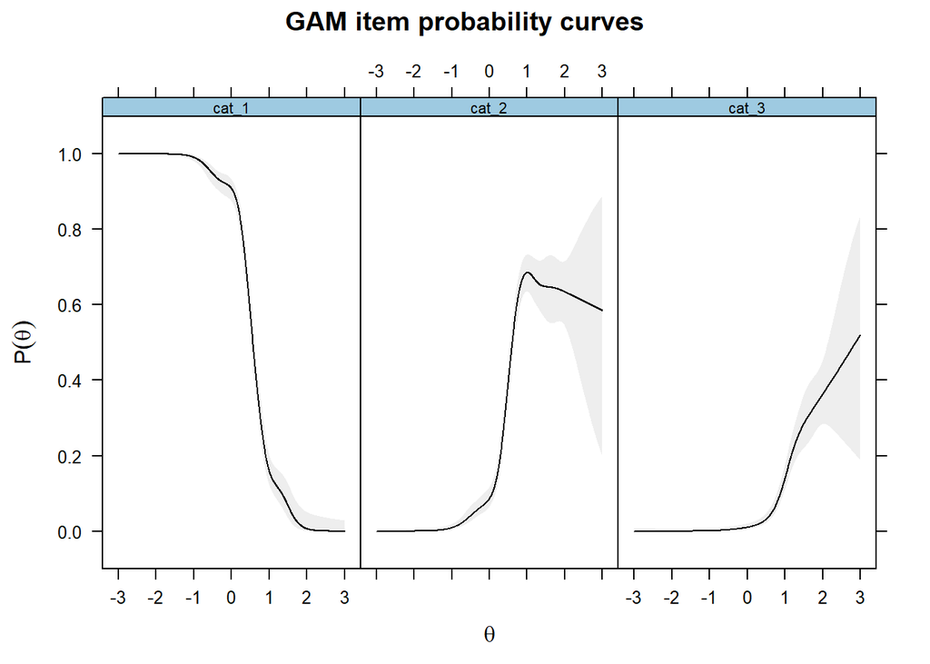

```r
plot(IG688); plot(IG689)
```

Next let’s look at the relationship between the true scores and the raw scores.

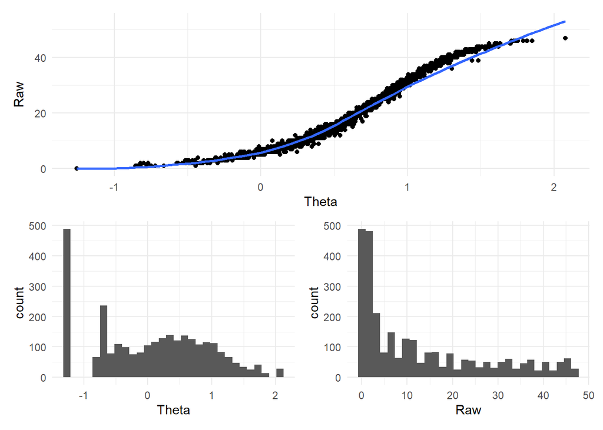

```r
true_raw <- Complex_short %>%
  mutate(
    Raw = rowSums(.[,1:42]),
    Theta = fscores(m1, method="MAP")
  ) %>%
  ggplot(aes(x=Theta, y=Raw)) + geom_point() + stat_smooth(method="loess") + theme_minimal()

raw_score <- Complex_short %>%
  mutate(
    Raw = rowSums(.[,1:42])
    ) %>%
   ggplot(aes(x=Raw)) + geom_histogram() + theme_minimal()

true_score <- Complex_short %>%
  mutate(
    Theta = fscores(m1, method="MAP")
    ) %>%
   ggplot(aes(x=Theta)) + geom_histogram() + theme_minimal()

library(patchwork)

true_raw/(true_score + raw_score)
```

Well, we’re getting a little more sensitivity at the lower end of the scale than we had before, and the results are starting to look a bit closer to gaussian-ish.

Next let’s take a look at the difficulty and discrimination parameter for each item.

Note to self: This block of code will need to be fixed if I treat variables as ordinal, as the output of `coef` is now different.

```r
#coefs_2pl <- coef(m1, as.data.frame = TRUE) %>%
# t() %>%
#  as_tibble() %>%
#  dplyr::select(-c(149:150)) %>%
#  pivot_longer(everything()) %>%
#  separate(, col=name, into=c("item", "parameter"), sep="([.])") %>%
#  pivot_wider(id_cols=item, names_from=parameter, values_from=value) %>%
#  dplyr::select(item, a1, d) %>%
#  mutate(
#   category =  gsub('[[:digit:]]+', '', item)
#  )

#ggplot(coefs_2pl,
#       aes(x = a1, y = d)) +
#  geom_point(alpha = .3) +
#  ggrepel::geom_text_repel(data = coefs_2pl,
#                  aes(label = item), size = 3) +
#  xlab("Discrimination") +
#  ylab("Difficulty") + theme_minimal()
```

```r
#ggplot(coefs_2pl, aes(x=a1, fill=category)) + geom_histogram() + theme_minimal()
#ggplot(coefs_2pl, aes(x=d, fill=category)) + geom_histogram() + theme_minimal()
```

I was worried that the over-regularization and irregular items would be non-monotonically related to the factor scores, since we expect children to go through qualitatively distinct stages. So I summed these sections and plotted them against the factor score below.

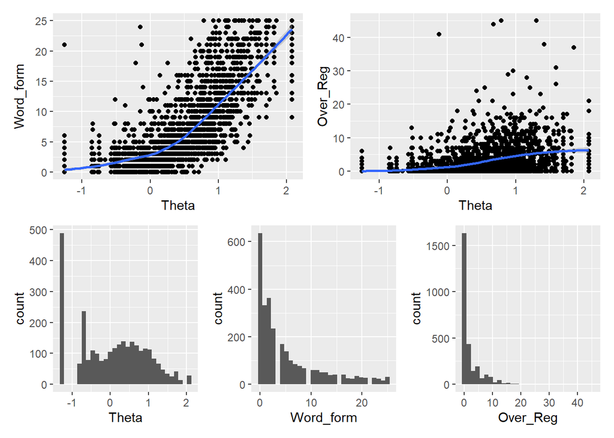

```r
Theta_by_Wordforms <- Complex_short_with_ids %>%
  mutate(
    rn = row_number()
  ) %>%
  transmute(
    Word_form = rowSums(.[,6:30]),
    Over_Reg = rowSums(.[,31:75]),
    Theta = as.numeric(fscores(m1, "MAP"))
  )

p1 <- ggplot(Theta_by_Wordforms, aes(x=Theta, y=Word_form)) + geom_point() + stat_smooth(method="loess")
p2 <- ggplot(Theta_by_Wordforms, aes(x=Theta, y=Over_Reg)) + geom_point() + stat_smooth(method="loess")
p3 <- ggplot(Theta_by_Wordforms, aes(x=Theta)) + geom_histogram()
p4 <- ggplot(Theta_by_Wordforms, aes(x=Word_form)) + geom_histogram()
p5 <- ggplot(Theta_by_Wordforms, aes(x=Over_Reg)) + geom_histogram()

(p1 | p2)/(p3 | p4 | p5)
```

Interesting to see that neither is clearly non-monotonic, even though that’s what we would expect from theories of language acquisition.

Now I’m going to try adding each of those sets of variables to the model I fit above. I do the word forms first and then the over-regularization

# 3 Adding Word Forms.

```r
Complex_short_with_ids <- Complex %>%
  dplyr::select(data_id, value, out, complexity_category, num_item_id) %>%
  mutate(
    label = str_c(complexity_category, num_item_id)
  ) %>%
  pivot_wider(id_cols=data_id, names_from = "label", values_from="out") %>%
  drop_na()


Complex_short <- Complex_short_with_ids %>%
  dplyr::select(starts_with(c("combine", "morphology", "syntax", "word_forms")), c("word_endings686", "word_endings687", "word_endings688", "word_endings689")) # dataset for IRT can't have IDs
```

```r
Complex_poly <- polychoric(Complex_short)
```

```r
rho <- Complex_poly$rho

lab = c("1", "2", "3", "4", "5", "6", "7", "8", "9", "10", "11", "12", "13", "14", "15", "16", "17", "18", "19", "20", "21", "22", "23", "24", "25", "26", "27", "28", "29", "30", "31", "32", "33", "34", "35", "36", "37", "38", "39", "40", "41", "42", "43", "44", "45", "46", "47", "48", "49", "50", "51", "52", "53", "54", "55", "56", "57", "58", "59", "60",
"61", "62", "63", "64", "65", "66", "67") # create labels for corPlot because the defintions are long and take up a ton of space
```

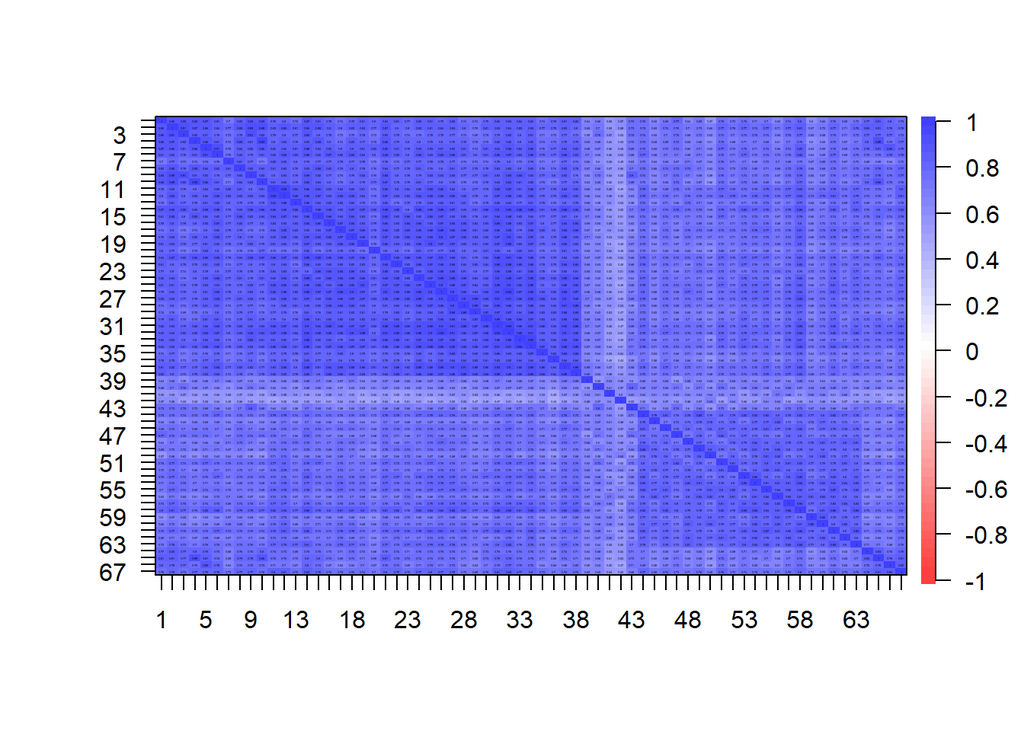

```r
corPlot(rho, labels=lab)
```

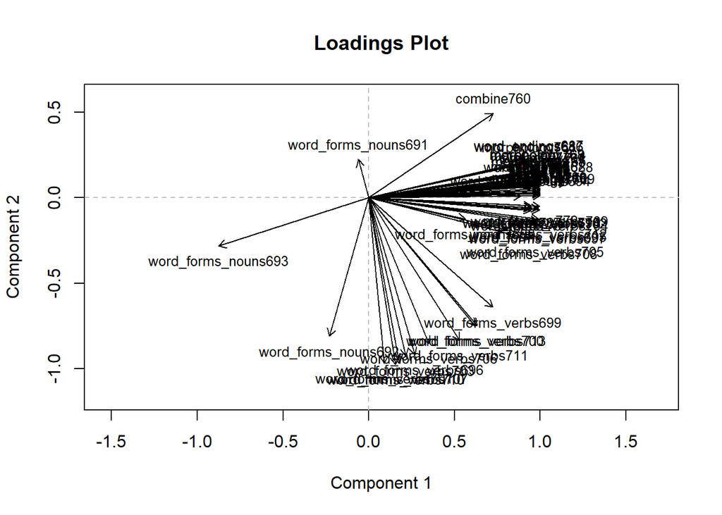

```r
pc <- princals(rho)

plot(pc)
```

Looks like there’s a big clumb of vectors in one area but then way more pointing out in random directions, which I think will create some fit issues.

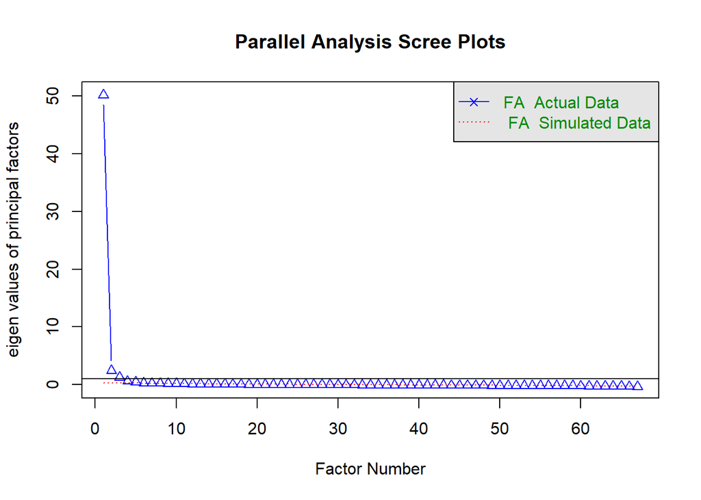

```
## Parallel analysis suggests that the number of factors =  8  and the number of components =  NA
```

```r
fa.parallel(rho, fa="fa", cor="poly", n.obs = 2785)
```

```r
vss(rho, fa="fa", cor="tet", n.obs = 2785)
```

[output not shown]

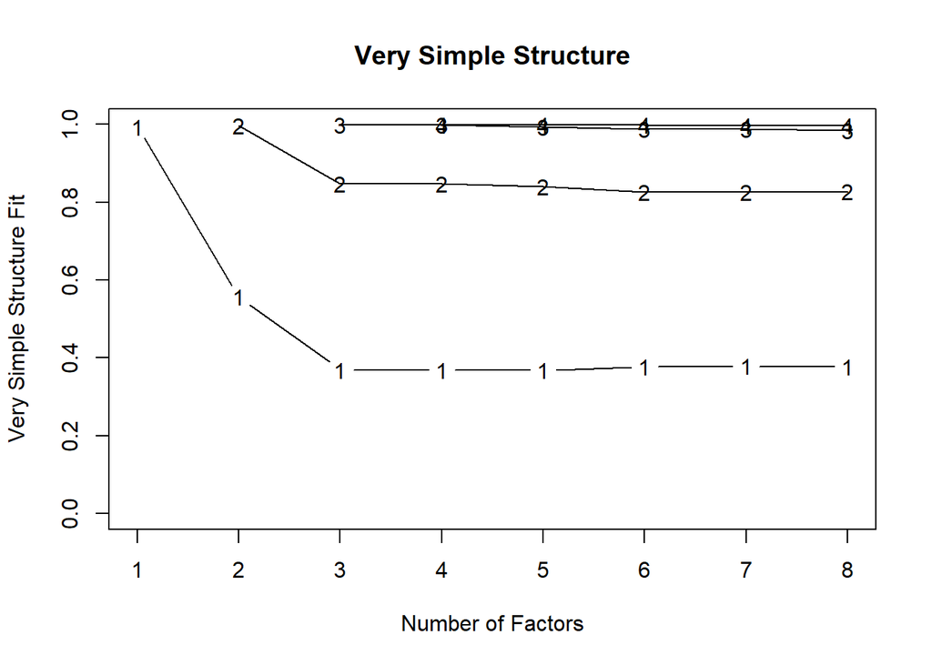

```
##
## Very Simple Structure
## Call: vss(x = rho, n.obs = 2785, cor = "tet", fa = "fa")
## VSS complexity 1 achieves a maximimum of 0.99  with  1  factors
## VSS complexity 2 achieves a maximimum of 1  with  2  factors
##
## The Velicer MAP achieves a minimum of 0.01  with  5  factors
## BIC achieves a minimum of  359826.3  with  8  factors
## Sample Size adjusted BIC achieves a minimum of  365237.3  with  8  factors
##
## Statistics by number of factors
##   vss1 vss2   map  dof  chisq prob sqresid  fit RMSEA    BIC  SABIC complex
## 1 0.99 0.00 0.035 2144 426325    0    14.4 0.99  0.27 409319 416131     1.0
## 2 0.56 1.00 0.018 2078 403934    0     7.0 1.00  0.26 387451 394054     1.7
## 3 0.37 0.85 0.013 2013 391590    0     4.7 1.00  0.26 375623 382019     2.2
## 4 0.37 0.85 0.013 1949 385741    0     4.1 1.00  0.27 370282 376474     2.3
## 5 0.37 0.84 0.012 1886 382110    0     3.4 1.00  0.27 367150 373142     2.4
## 6 0.38 0.83 0.012 1824 378989    0     3.1 1.00  0.27 364521 370316     2.5
## 7 0.38 0.83 0.012 1763 376197    0     2.8 1.00  0.28 362213 367815     2.5
## 8 0.38 0.83 0.013 1703 373335    0     2.6 1.00  0.28 359826 365237     2.5
##   eChisq  SRMR eCRMS   eBIC
## 1  26667 0.047 0.047   9661
## 2   9604 0.028 0.029  -6879
## 3   5044 0.020 0.021 -10923
## 4   3928 0.018 0.019 -11531
## 5   3050 0.016 0.017 -11909
## 6   2636 0.015 0.016 -11832
## 7   2352 0.014 0.015 -11632
## 8   2065 0.013 0.015 -11443
```

```r
m2 <- mirt(Complex_short, 1, itemtype="graded", verbose=FALSE)

summary(m2)
```

```
##                        F1    h2
## combine760          0.894 0.799
## morphology761       0.924 0.853
## morphology762       0.894 0.800
## morphology763       0.900 0.809
## morphology764       0.919 0.845
## morphology765       0.932 0.869
## morphology766       0.882 0.778
## morphology767       0.897 0.805
## morphology768       0.905 0.820
## morphology769       0.905 0.819
## morphology770       0.941 0.885
## morphology771       0.955 0.911
## morphology772       0.927 0.860
## syntax773           0.952 0.906
## syntax774           0.928 0.861
## syntax775           0.939 0.882
## syntax776           0.953 0.909
## syntax777           0.947 0.898
## syntax778           0.930 0.866
## syntax779           0.891 0.794
## syntax780           0.943 0.889
## syntax781           0.925 0.855
## syntax782           0.929 0.864
## syntax783           0.949 0.901
## syntax784           0.944 0.890
## syntax785           0.963 0.927
## syntax786           0.962 0.926
## syntax787           0.961 0.923
## syntax788           0.933 0.871
## syntax789           0.930 0.864
## syntax790           0.961 0.924
## syntax791           0.964 0.929
## syntax792           0.939 0.881
## syntax793           0.960 0.922
## syntax794           0.928 0.861
## syntax795           0.902 0.814
## syntax796           0.962 0.926
## syntax797           0.950 0.902
## word_forms_nouns690 0.811 0.658
```

[output cut: 21 more lines]

```
## word_forms_verbs712 0.920 0.846
## word_forms_verbs713 0.877 0.768
## word_forms_verbs714 0.910 0.827
## word_endings686     0.834 0.696
## word_endings687     0.855 0.731
## word_endings688     0.846 0.716
## word_endings689     0.894 0.799
##
## SS loadings:  54.503
## Proportion Var:  0.813
##
## Factor correlations:
##
##    F1
## F1  1
```

```r
M2(m2)
```

|  | M2 | df | p | RMSEA | RMSEA_5 | RMSEA_95 | SRMSR | TLI | CFI |
| --- | --- | --- | --- | --- | --- | --- | --- | --- | --- |
| stats | 18491.06 | 2139 | 0 | 0.0524018 | 0.05169816 | 0.05308937 | 0.06081494 | 0.9879092 | 0.9882764 |

```r
m2b <- mirt(Complex_short, 2, "graded", verbose=FALSE)
```

```r
summary(m2b, "oblimin", suppress=.20)
```

```
##
## Rotation:  oblimin
##
## Rotated factor loadings:
##
##                         F1    F2    h2
## combine760          -0.941    NA 0.823
## morphology761       -0.913    NA 0.862
## morphology762       -0.767    NA 0.802
## morphology763       -0.992    NA 0.832
## morphology764       -0.952    NA 0.859
## morphology765       -0.910    NA 0.876
## morphology766       -0.679 0.218 0.772
## morphology767       -0.868    NA 0.813
## morphology768       -0.856    NA 0.828
## morphology769       -1.044    NA 0.848
## morphology770       -0.733 0.223 0.878
## morphology771       -0.750 0.220 0.905
## morphology772       -0.834    NA 0.858
## syntax773           -0.923    NA 0.914
## syntax774           -0.946    NA 0.873
## syntax775           -0.975    NA 0.896
## syntax776           -0.845    NA 0.907
## syntax777           -0.938    NA 0.904
## syntax778           -1.005    NA 0.884
## syntax779           -0.919    NA 0.804
## syntax780           -0.955    NA 0.901
## syntax781           -0.889    NA 0.862
## syntax782           -0.851    NA 0.864
## syntax783           -0.994    NA 0.914
## syntax784           -0.869    NA 0.893
## syntax785           -0.933    NA 0.933
## syntax786           -0.931    NA 0.932
## syntax787           -0.907    NA 0.926
## syntax788           -0.976    NA 0.885
## syntax789           -0.951    NA 0.876
## syntax790           -0.973    NA 0.935
## syntax791           -0.982    NA 0.941
## syntax792           -0.946    NA 0.893
## syntax793           -0.906    NA 0.927
```

[output cut: 26 more lines]

```
## word_forms_verbs712 -0.251 0.703 0.870
## word_forms_verbs713     NA 0.908 0.835
## word_forms_verbs714 -0.260 0.680 0.845
## word_endings686     -0.692    NA 0.695
## word_endings687     -0.793    NA 0.737
## word_endings688     -0.582 0.281 0.708
## word_endings689         NA 0.727 0.778
##
## Rotated SS loadings:  34.058 17.043
##
## Factor correlations:
##
##        F1     F2
## F1  1.000 -0.888
## F2 -0.888  1.000
```

It looks like the word forms are loading consistently on a different factor from the morphosyntactic complexity factor.

Another possibility is that all of those items are guesses–especially since they’re means are all low.

# 4 Adding Overregularizations.

```r
Complex_short_with_ids <- Complex %>%
  dplyr::select(data_id, value, out, complexity_category, num_item_id) %>%
  mutate(
    label = str_c(complexity_category, num_item_id)
  ) %>%
  pivot_wider(id_cols=data_id, names_from = "label", values_from="out") %>%
  drop_na()


Complex_short <- Complex_short_with_ids %>%
  dplyr::select(starts_with(c("combine", "morphology", "syntax", "word_endings"))) # dataset for IRT can't have IDs
```

```r
Complex_poly <- polychoric(Complex_short)
```

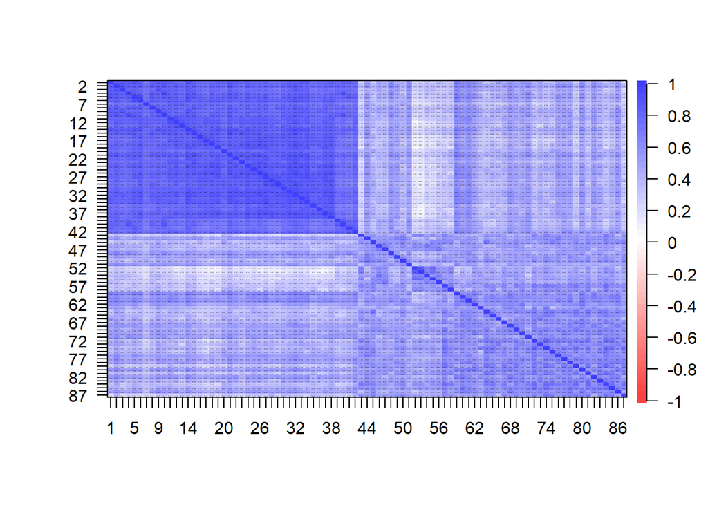

```r
rho <- Complex_poly$rho

lab = c("1", "2", "3", "4", "5", "6", "7", "8", "9", "10", "11", "12", "13", "14", "15", "16", "17", "18", "19", "20", "21", "22", "23", "24", "25", "26", "27", "28", "29", "30", "31", "32", "33", "34", "35", "36", "37", "38", "39", "40", "41", "42", "43", "44", "45", "46", "47", "48", "49", "50", "51", "52", "53", "54", "55", "56", "57", "58", "59", "60",
"61", "62", "63", "64", "65", "66", "67", "68", "69", "70", "71", "72", "73", "74", "75", "76", "77", "78", "79", "80",
"81", "82", "83", "84", "85", "86", "87" ) # create labels for corPlot because the defintions are long and take up a ton of space

corPlot(rho, labels=lab)
```

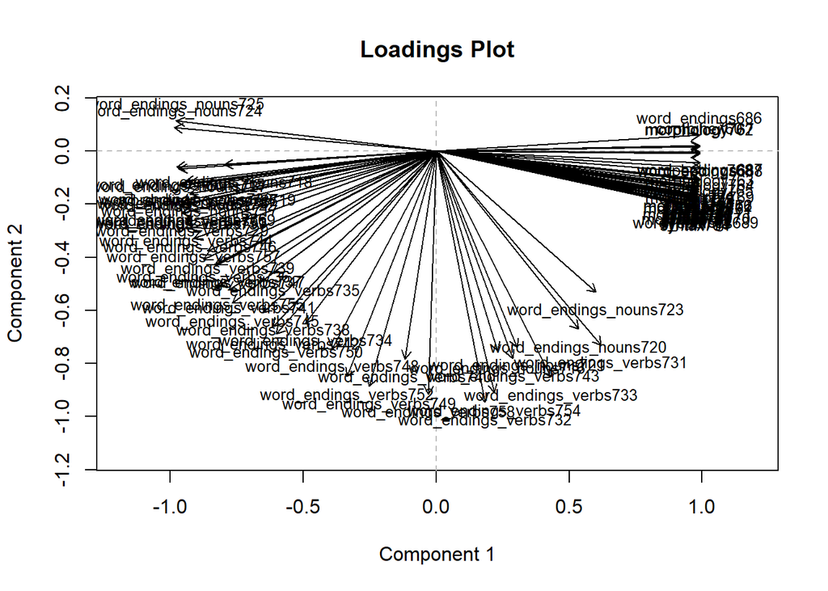

```r
pc <- princals(rho)
plot(pc)
```

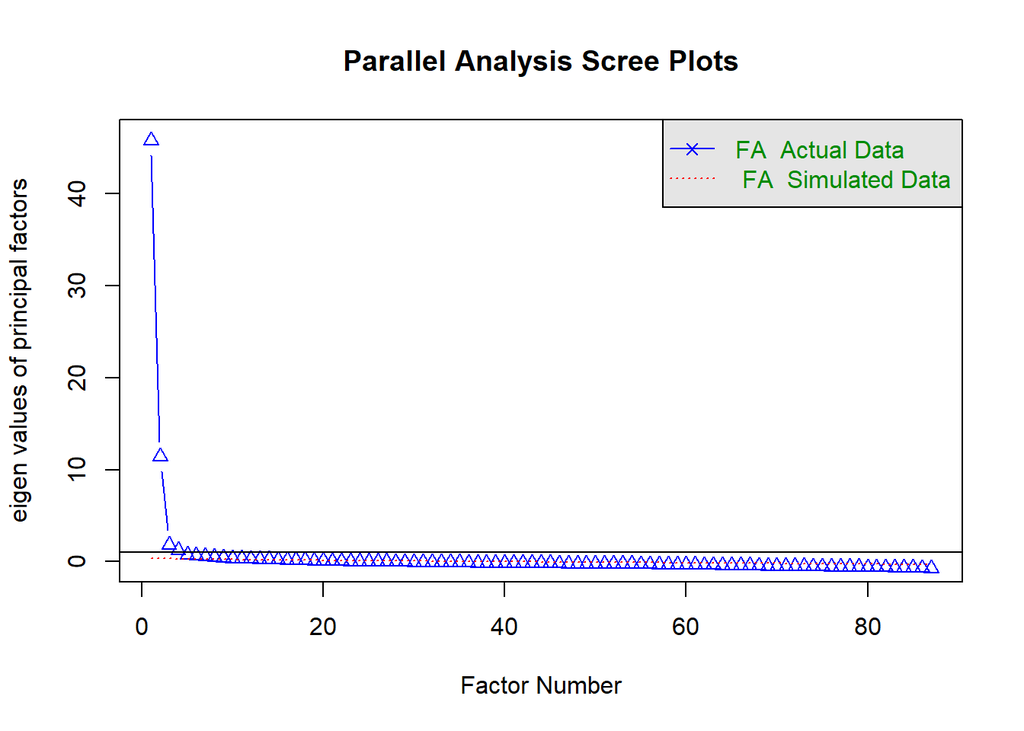

```
## Parallel analysis suggests that the number of factors =  15  and the number of components =  NA
```

```r
fa.parallel(rho, fa="fa", cor="tet", n.obs = 2785)
```

```r
vss(rho, fa="fa", cor="tet", n.obs = 2785)
```

[output not shown]

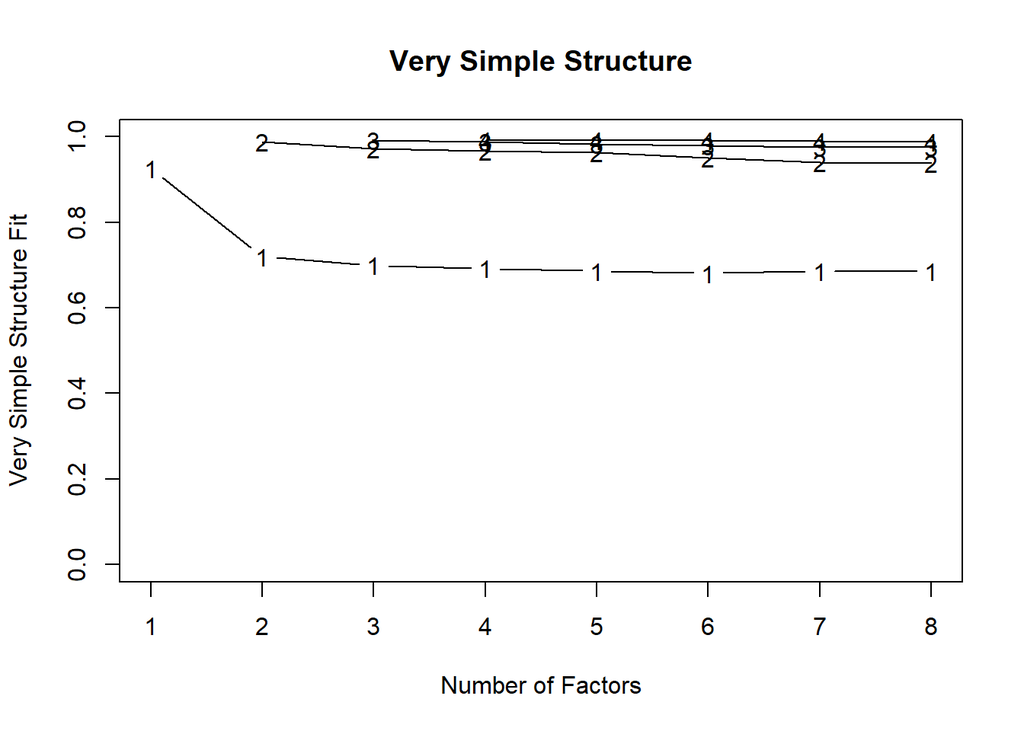

```
##
## Very Simple Structure
## Call: vss(x = rho, n.obs = 2785, cor = "tet", fa = "fa")
## VSS complexity 1 achieves a maximimum of 0.93  with  1  factors
## VSS complexity 2 achieves a maximimum of 0.99  with  2  factors
##
## The Velicer MAP achieves a minimum of 0.01  with  5  factors
## BIC achieves a minimum of  1230373  with  8  factors
## Sample Size adjusted BIC achieves a minimum of  1240137  with  8  factors
##
## Statistics by number of factors
##   vss1 vss2   map  dof   chisq prob sqresid  fit RMSEA     BIC   SABIC complex
## 1 0.93 0.00 0.089 3654 1359800    0     169 0.93  0.37 1330816 1342426     1.0
## 2 0.72 0.99 0.017 3568 1293765    0      26 0.99  0.36 1265464 1276801     1.3
## 3 0.70 0.97 0.015 3483 1281702    0      20 0.99  0.36 1254075 1265142     1.4
## 4 0.69 0.97 0.014 3399 1274046    0      17 0.99  0.37 1247085 1257885     1.5
## 5 0.69 0.96 0.014 3316 1268498    0      15 0.99  0.37 1242196 1252732     1.6
## 6 0.68 0.95 0.014 3234 1263953    0      14 0.99  0.37 1238301 1248576     1.7
## 7 0.69 0.94 0.014 3153 1259157    0      13 0.99  0.38 1234147 1244165     1.7
## 8 0.69 0.94 0.014 3073 1254748    0      11 1.00  0.38 1230373 1240137     1.8
##   eChisq  SRMR eCRMS   eBIC
## 1 407904 0.140 0.142 378921
## 2  39389 0.043 0.045  11087
## 3  27362 0.036 0.038   -265
## 4  21675 0.032 0.034  -5286
## 5  19086 0.030 0.032  -7217
## 6  17125 0.029 0.031  -8527
## 7  15278 0.027 0.029  -9731
## 8  13617 0.026 0.028 -10758
```

```r
m3b <- mirt(Complex_short, 2, "graded", verbose=FALSE)
```

```
## EM cycles terminated after 500 iterations.
```

```r
summary(m3b, "oblimin", suppress=.20)
```

```
##
## Rotation:  oblimin
##
## Rotated factor loadings:
##
##                           F1     F2    h2
## combine760                NA  0.978 0.835
## morphology761             NA  0.908 0.867
## morphology762             NA  0.883 0.806
## morphology763             NA  0.954 0.838
## morphology764             NA  0.935 0.865
## morphology765             NA  0.920 0.883
## morphology766             NA  0.901 0.784
## morphology767             NA  0.889 0.822
## morphology768             NA  0.907 0.831
## morphology769             NA  0.940 0.848
## morphology770             NA  0.871 0.893
## morphology771             NA  0.922 0.915
## morphology772             NA  0.914 0.877
## syntax773                 NA  0.965 0.920
## syntax774                 NA  0.943 0.881
## syntax775                 NA  0.971 0.901
## syntax776                 NA  0.946 0.916
## syntax777                 NA  0.984 0.911
## syntax778                 NA  0.974 0.888
## syntax779                 NA  0.854 0.816
## syntax780                 NA  0.944 0.906
## syntax781                 NA  0.910 0.869
## syntax782                 NA  0.950 0.875
## syntax783                 NA  0.936 0.918
## syntax784                 NA  0.920 0.902
## syntax785                 NA  0.965 0.939
## syntax786                 NA  0.919 0.939
## syntax787                 NA  0.897 0.940
## syntax788                 NA  0.871 0.903
## syntax789                 NA  0.907 0.881
## syntax790                 NA  0.944 0.938
## syntax791                 NA  0.955 0.944
## syntax792                 NA  0.916 0.897
## syntax793                 NA  0.937 0.932
```

[output cut: 46 more lines]

```
## word_endings_verbs753 -0.881     NA 0.859
## word_endings_verbs754 -0.633  0.337 0.822
## word_endings_verbs755 -0.778     NA 0.830
## word_endings_verbs756 -0.879     NA 0.916
## word_endings_verbs757 -0.793     NA 0.848
## word_endings_verbs758 -0.662  0.312 0.834
## word_endings_verbs759 -0.833     NA 0.825
##
## Rotated SS loadings:  27.328 37.616
##
## Factor correlations:
##
##        F1     F2
## F1  1.000 -0.721
## F2 -0.721  1.000
```

As was the case with the word form variables, all of the word endings variables loaded onto a separate factor from the morphosyntactic complexity variables.

# 5 Quick Interim Summary

So a quick re-cap: I was concerned about including the word form and over-regularizations variables to the IRT models because they are theoretically non-monotonically related to syntactic proficiency. We would expect children to initially produce high frequency irregular forms, then go through a stage of over-regularization, and finally to produce the correct irregular word forms again. However, when I plotted the total scores on these subscales against a syntactic proficiency variable derived from the other subscales, I did not see evidence of a non-monotonic relationship. Rather in both cases, subscale scores increased with increasing syntactic proficiency, though it appeared to be leveling off for the over-regularizations.

I then tried fitting two more models, one that included the word form variables and another that included the overgeneralization variables. Exploration of the dimensionality suggested that adding these variables resulted in a much clearer multi-dimensional structure (see categorical PCAs and scree plots). In both cases, exploratory two dimensional IRTs indicated two-factor solutions in which one factor was dominated by the morphosyntactic complexity variables and the other was dominated by the word form or overregularization variables.

It’s difficult to say exactly what this means, as these results could plausibly be due to different psychological demands of learning the relevant structure or some sort of difference in reporting biases across the scales.

# 6 Final Model

I think I’m going to stick with the model that includes the complexity variable and the word endings variables as they seem to increase the sensitivity of the model to lower proficiency children and do not appear to affect the dimensionality much.

Get the data set back.

```r
Complex_short_with_ids <- Complex %>%
  dplyr::select(data_id, value, out, complexity_category, num_item_id) %>%
  mutate(
    label = str_c(complexity_category, num_item_id)
  ) %>%
  pivot_wider(id_cols=data_id, names_from = "label", values_from="out") %>%
  drop_na()


Complex_short <- Complex_short_with_ids %>%
  dplyr::select(starts_with(c("combine", "morphology", "syntax")), c("word_endings686", "word_endings687", "word_endings688", "word_endings689")) # dataset for IRT can't have IDs
```

```r
summary(m1)
```

```
##                    F1    h2
## combine760      0.909 0.826
## morphology761   0.931 0.867
## morphology762   0.899 0.808
## morphology763   0.913 0.833
## morphology764   0.930 0.865
## morphology765   0.940 0.883
## morphology766   0.885 0.783
## morphology767   0.906 0.821
## morphology768   0.912 0.832
## morphology769   0.920 0.846
## morphology770   0.942 0.887
## morphology771   0.955 0.911
## morphology772   0.933 0.870
## syntax773       0.959 0.919
## syntax774       0.938 0.880
## syntax775       0.949 0.901
## syntax776       0.956 0.914
## syntax777       0.954 0.909
## syntax778       0.941 0.886
## syntax779       0.900 0.810
## syntax780       0.952 0.906
## syntax781       0.932 0.869
## syntax782       0.935 0.875
## syntax783       0.957 0.916
## syntax784       0.949 0.900
## syntax785       0.968 0.938
## syntax786       0.968 0.937
## syntax787       0.964 0.930
## syntax788       0.943 0.889
## syntax789       0.938 0.880
## syntax790       0.968 0.937
## syntax791       0.972 0.944
## syntax792       0.947 0.897
## syntax793       0.966 0.932
## syntax794       0.935 0.874
## syntax795       0.915 0.838
## syntax796       0.968 0.937
## syntax797       0.954 0.910
## word_endings686 0.839 0.705
## word_endings687 0.865 0.748
## word_endings688 0.845 0.714
## word_endings689 0.886 0.784
##
## SS loadings:  36.511
## Proportion Var:  0.869
##
## Factor correlations:
##
##    F1
## F1  1
```

```r
M2(m1)
```

|  | M2 | df | p | RMSEA | RMSEA_5 | RMSEA_95 | SRMSR | TLI | CFI |
| --- | --- | --- | --- | --- | --- | --- | --- | --- | --- |
| stats | 4657.7 | 814 | 0 | 0.04118394 | 0.04003188 | 0.04232945 | 0.06276226 | 0.9941674 | 0.9944536 |

## 6.1 More formal tests of the dimensionality

```r
m1b <- mirt(Complex_short, 2, "graded", verbose=FALSE)
```

```r
anova(m1, m1b)
```

```
##
## Model 1: mirt(data = Complex_short, model = 1, itemtype = "graded", verbose = FALSE)
## Model 2: mirt(data = Complex_short, model = 2, itemtype = "graded", verbose = FALSE)
```

| AIC | AICc | SABIC | HQ | BIC | logLik | X2 | df | p |
| --- | --- | --- | --- | --- | --- | --- | --- | --- |
| 68691.36 | 68697.31 | 68936.53 | 68881.99 | 69219.31 | -34256.68 | NaN | NaN | NaN |
| 67797.61 | 67810.44 | 68155.72 | 68076.05 | 68568.77 | -33768.81 | 975.7535 | 41 | 0 |

```r
summary(m1b, "oblimin", suppress=.2)
```

```
##
## Rotation:  oblimin
##
## Rotated factor loadings:
##
##                     F1     F2    h2
## combine760      -0.882     NA 0.822
## morphology761   -0.883     NA 0.876
## morphology762   -0.861     NA 0.802
## morphology763   -0.818  0.389 0.923
## morphology764   -0.894     NA 0.859
## morphology765   -0.920     NA 0.865
## morphology766   -0.858     NA 0.761
## morphology767   -0.861     NA 0.815
## morphology768   -0.894     NA 0.821
## morphology769   -0.843  0.327 0.908
## morphology770   -0.916     NA 0.877
## morphology771   -0.931     NA 0.907
## morphology772   -0.906     NA 0.863
## syntax773       -0.947     NA 0.905
## syntax774       -0.906     NA 0.875
## syntax775       -0.936     NA 0.883
## syntax776       -0.954     NA 0.900
## syntax777       -0.945     NA 0.893
## syntax778       -0.939     NA 0.869
## syntax779       -0.895     NA 0.784
## syntax780       -0.925     NA 0.899
## syntax781       -0.934     NA 0.854
## syntax782       -0.919     NA 0.854
## syntax783       -0.958     NA 0.901
## syntax784       -0.953     NA 0.888
## syntax785       -0.967     NA 0.926
## syntax786       -0.979     NA 0.934
## syntax787       -0.982     NA 0.938
## syntax788       -0.961 -0.211 0.902
## syntax789       -0.942     NA 0.866
## syntax790       -0.973     NA 0.929
## syntax791       -0.972     NA 0.935
## syntax792       -0.951     NA 0.884
## syntax793       -0.973     NA 0.926
## syntax794       -0.939     NA 0.859
## syntax795       -0.922     NA 0.827
## syntax796       -0.977     NA 0.932
## syntax797       -0.962     NA 0.902
## word_endings686 -0.777  0.234 0.717
## word_endings687 -0.785  0.320 0.800
## word_endings688 -0.816     NA 0.690
## word_endings689 -0.863     NA 0.726
##
## Rotated SS loadings:  35.26 0.852
##
## Factor correlations:
##
##        F1     F2
## F1  1.000 -0.163
## F2 -0.163  1.000
```

We have a similar solution to what we had in the first version of this analysis. The factor model fits better but it’s not at all clear what the second factor is adding. Everything loads strongly on the first factor and very little on the second factor.

Comapre with 1 factor graded model with semi-parametric latent variable specification.

```r
m1_nonpar <- mirt(Complex_short, 1, itemtype="graded", dentype = "EH", verbose=FALSE)

M2(m1_nonpar)
```

|  | M2 | df | p | RMSEA | RMSEA_5 | RMSEA_95 | SRMSR | TLI | CFI |
| --- | --- | --- | --- | --- | --- | --- | --- | --- | --- |
| stats | 4976.326 | 814 | 0 | 0.04285694 | 0.04170873 | 0.04399787 | 0.2595351 | 0.9936839 | 0.9939938 |

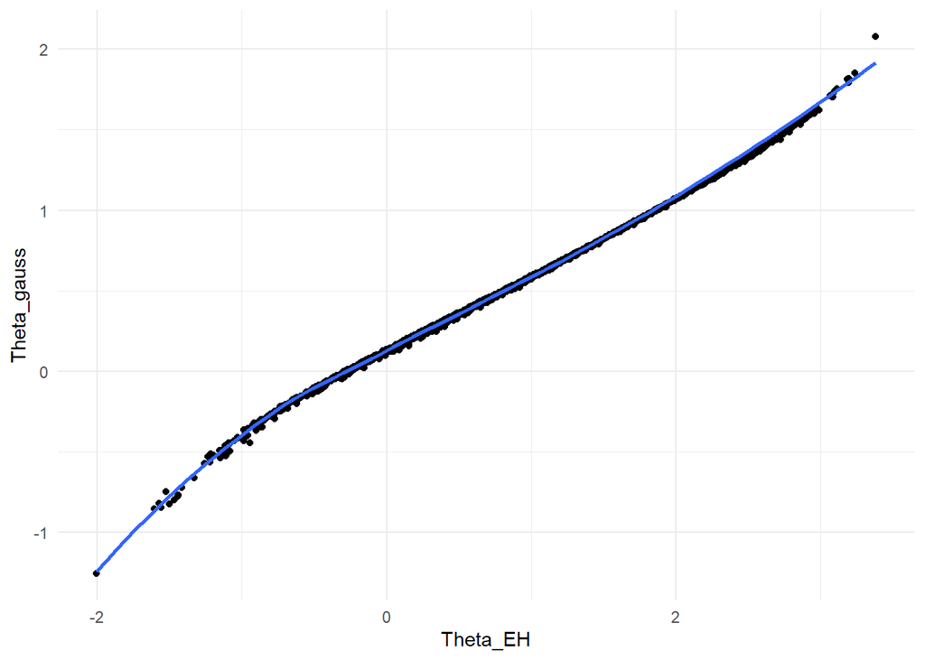

```r
Complex_short %>%
  mutate(
    Theta_EH = fscores(m1_nonpar, method="MAP"),
    Theta_gauss = fscores(m1, method="MAP")
  ) %>%
  ggplot(aes(x=Theta_EH, y=Theta_gauss)) + geom_point() + stat_smooth(method="loess") + theme_minimal()
```

```r
m1_nonpar2 <- mirt(Complex_short, 1, itemtype="graded", dentype = "EHW", verbose=FALSE)
```

```
## EM cycles terminated after 2000 iterations.
```

```r
M2(m1_nonpar2)
```

|  | M2 | df | p | RMSEA | RMSEA_5 | RMSEA_95 | SRMSR | TLI | CFI |
| --- | --- | --- | --- | --- | --- | --- | --- | --- | --- |
| stats | 5197.067 | 814 | 0 | 0.04397869 | 0.04283279 | 0.04511679 | 0.09902156 | 0.993349 | 0.9936753 |

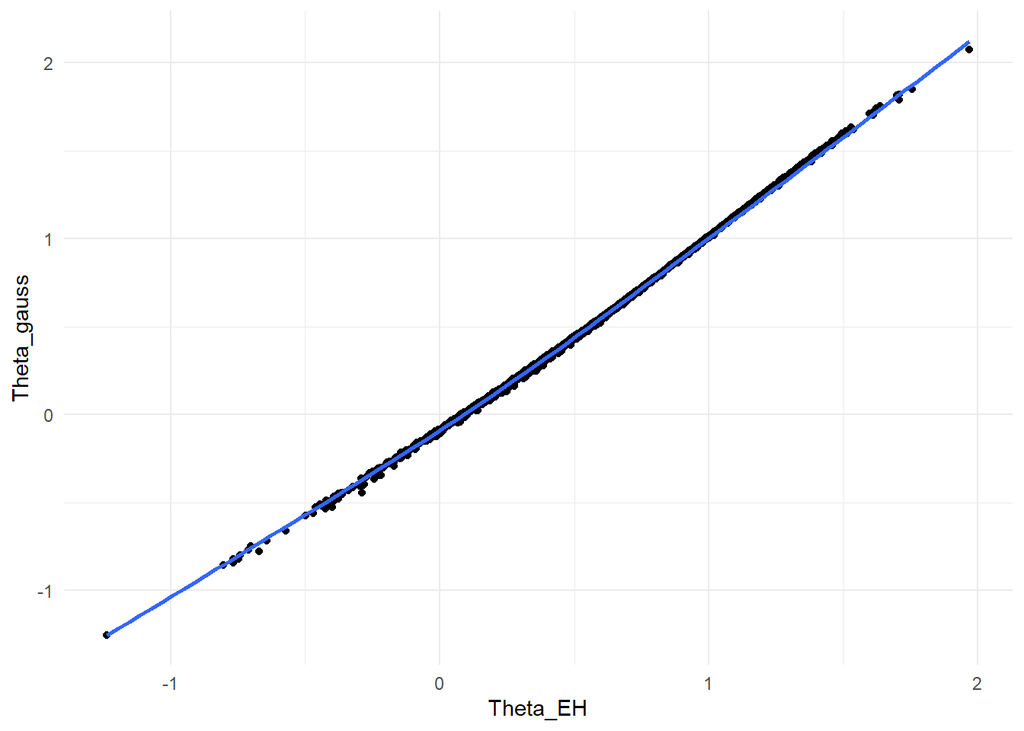

```r
Complex_short %>%
  mutate(
    Theta_EH = fscores(m1_nonpar2, method="MAP"),
    Theta_gauss = fscores(m1, method="MAP")
  ) %>%
  ggplot(aes(x=Theta_EH, y=Theta_gauss)) + geom_point() + stat_smooth(method="loess") + theme_minimal()
```

These semi-parametric alternatives look pretty similar. I think in both cases, the Gaussian model is a bit easier to interpret and will likely make it easier to work with other functionality.

# 7 Measurement invariance.

I mentioned in the last meeting that these models assume measusrement invariance – basically the probability of producing an item is the same for two children of the same estimated ability who differ according to some other grouping variable. I have begun to assess this, using differential item functioning technques using some of the predictors in the data set. I should say, I’m out over my skis a bit here at this point.

Create data sets with predictor variables for

```r
Complex_short_with_ids <- Complex %>%
  dplyr::select(data_id, value, out, complexity_category, num_item_id) %>%
  mutate(
    label = str_c(complexity_category, num_item_id)
  ) %>%
  dplyr::select(data_id, label, out) %>%
  pivot_wider(id_cols=data_id, names_from = "label", values_from="out") %>%
  drop_na()
```

```r
Complex_short <- Complex_short_with_ids %>%
  dplyr::select(starts_with(c("combine", "morphology", "syntax")), c("word_endings686", "word_endings687", "word_endings688", "word_endings689")) # dataset for IRT can't have IDs
```

```r
Complex_with_predictors <- Admin %>%
  dplyr::select(data_id, age, ethnicity, sex) %>%
  mutate(
    female = ifelse(sex=="Female", yes=1, no=0),
    age_y = ifelse(age < 25, yes=1, no=0)
  ) %>%
  right_join(., Complex_short_with_ids, by="data_id")
```

```r
Complex_with_predictors %>%
  summarise(
    age_missing = sum(is.na(age)),
    ethnicity_missing = sum(is.na(ethnicity)), # Some ethnicity variables missing.
    sex_missing = sum(is.na(sex))
  )
```

| age_missing | ethnicity_missing | sex_missing |
| --- | --- | --- |
| 0 | 70 | 0 |

```r
table(Complex_with_predictors$age)
```

```
##
##  16  17  18  19  20  21  22  23  24  25  26  27  28  29  30
## 185 133 323 219 172 110 112 136 420 246 142 138 104 118 227
```

```r
table(Complex_with_predictors$ethnicity)
```

```
##
##    Asian    Black    Other    White Hispanic
##       67      222       93     2202      131
```

```r
table(Complex_with_predictors$sex)
```

```
##
## Female   Male  Other
##   1372   1413      0
```

Use lordif to look for DIF. I’ll start with sex first. I’ve not included the code here, the lordif function, which I used, does not allow verbose=FALSE so it produces a lot of extra information.

```r
dif
```

```
## Call:
## lordif(resp.data = Complex_short2, group = Complex_with_predictors$female,
##     criterion = "Chisqr", alpha = 0.01)
##
##   Number of DIF groups: 2
##
##   Number of items flagged for DIF: 2 of 42
##
##   Items flagged: 32, 41
##
##   Number of iterations for purification: 2 of 10
##
##   Detection criterion: Chisqr
##
##   Threshold: alpha = 0.01
```

[output cut: 44 more lines]

```r
plot(dif)
```

[output not shown]

Only two items have DIF and they look pretty similar across the two groups te be honest.

Every single item has Dif:

```r
dif
```

```
## Call:
## lordif(resp.data = Complex_short2, group = Complex_with_predictors$age_y,
##     criterion = "Chisqr", alpha = 0.01)
##
##   Number of DIF groups: 2
##
##   Number of items flagged for DIF: 42 of 42
##
##   Items flagged: 1, 2, 3, 4, 5, 6, 7, 8, 9, 10, 11, 12, 13, 14, 15, 16, 17, 18, 19, 20, 21, 22, 23, 24, 25, 26, 27, 28, 29, 30, 31, 32, 33, 34, 35, 36, 37, 38, 39, 40, 41, 42
##
##   Number of iterations for purification: 9 of 10
##
##   Detection criterion: Chisqr
##
##   Threshold: alpha = 0.01
```

[output cut: 44 more lines]

I can’t get plots I had above, because every item has dif – the factor scores can’t be equated in any reasonable way.

Plot the distribution of scores by age group to see what’s going on.

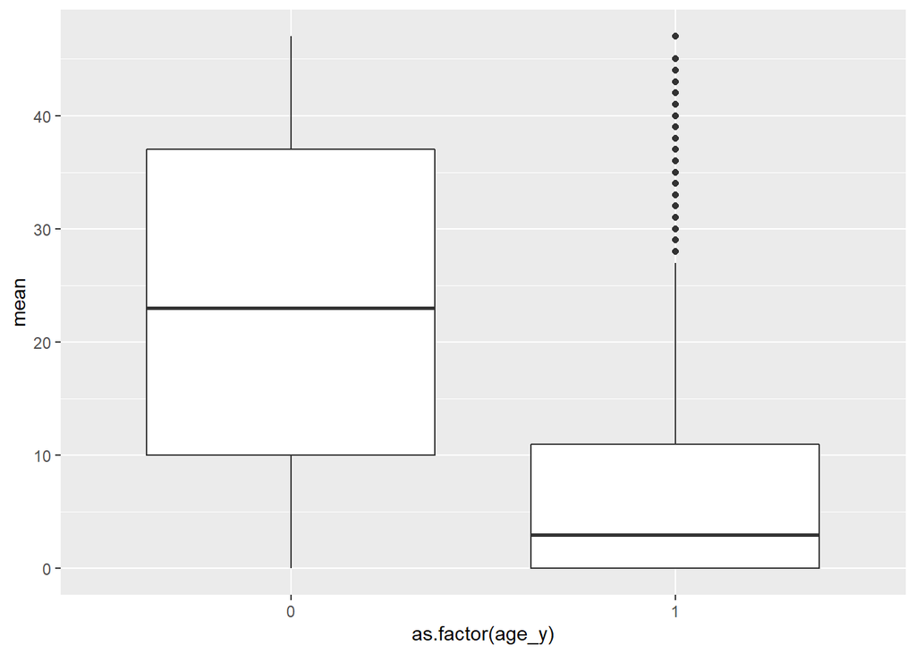

```r
Complex_with_predictors %>%
  dplyr::select(starts_with(c("morphology", "syntax", "combine")) , c("word_endings686", "word_endings687", "word_endings688", "word_endings689",  "age_y")) %>%
  mutate(
    mean = rowSums(.[1:42])
  ) %>%
  ggplot(aes(y=mean, x=as.factor(age_y))) + geom_boxplot()
```

# 8 Plot Theta against age and vocabulary.

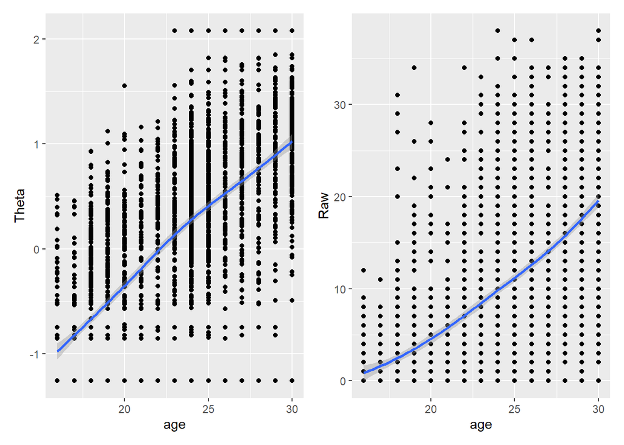

```r
by_Participant <-Complex_short_with_ids %>%
  mutate(
    Theta = fscores(m1, method="MAP")[,1],
    Raw = rowSums(.[2:38])
    ) %>%
  dplyr::select(data_id, Raw, Theta) %>%
  full_join(Complex) %>%
  group_by(data_id) %>%
  slice(1)
theta_by_age <- by_Participant %>%
  ggplot(aes(x=age, y=Theta)) + geom_point() + stat_smooth(method="loess")

raw_by_age <- by_Participant %>%
  ggplot(aes(x=age, y=Raw)) + geom_point() + stat_smooth(method="loess")

theta_by_age | raw_by_age
```

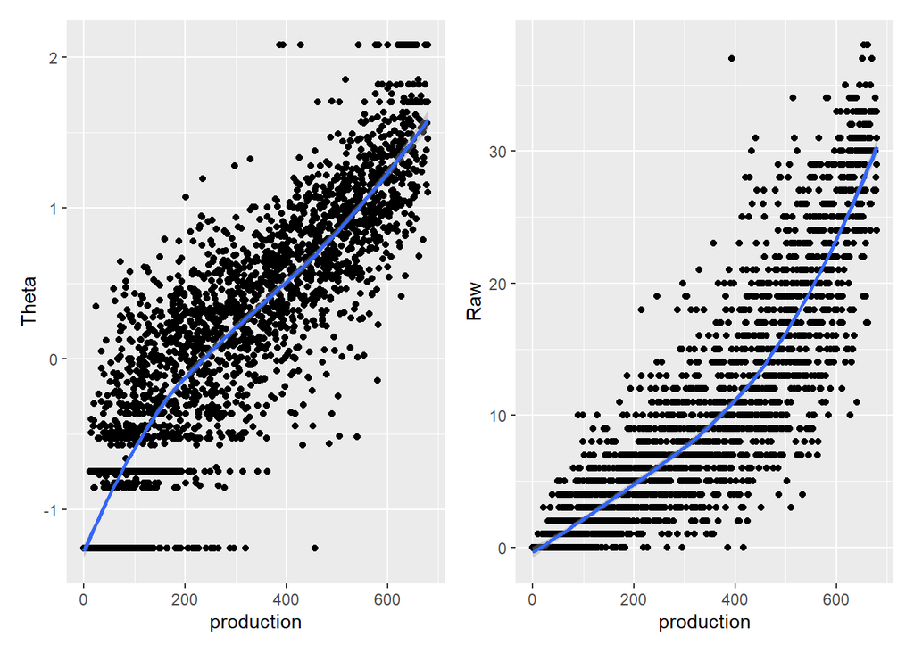

```r
theta_by_prod <- by_Participant %>%
  ggplot(aes(x=production, y=Theta)) + geom_point() + stat_smooth(method="loess")

raw_by_prod <- by_Participant %>%
  ggplot(aes(x=production, y=Raw)) + geom_point() + stat_smooth(method="loess")

theta_by_prod | raw_by_prod
```